# A/B test: Mobile game

Hampus Nordholm

2025-07-30

# Objective

Evaluate the effect of increasing the level gate from level 30 to 40 on Day 1 user retention in a mobile game. The test design follows a randomized controlled trial. A required sample size of 9,712 users per group, with a minimum detectable effect (MDE) of 2%, was determined and fulfilled according to power analysis.

# Sample sanity check

Test if group assignment is balanced.

```
##
##  Chi-squared test for given probabilities
##
## data:  table(ab_tbl$version)
## X-squared = 6.9024, df = 1, p-value = 0.008608
```

The chi-squared test indicates a statistically significant imbalance between group sizes (p < 0.01). Although assignment was randomized, the observed difference may be due to sampling variability.

# A/B test results

Two-sample test for difference in retention proportions.

**Null hypothesis:** There is no significant difference in DAY 1 retention rate between gate 30 and gate 40.

**Alternative hypothesis:** There is a statistically significant difference in retention rate between gate 30 and gate 40.

```
##
## 📊 AB-test: Proportiontest
## # A tibble: 2 × 3
##   version retained total
##   <chr>      <int> <int>
## 1 gate_30    20034 44700
## 2 gate_40    20119 45489
##
## ---
##
##  2-sample test for equality of proportions with continuity correction
##
## data:  ab_summary$retained out of ab_summary$total
## X-squared = 3.1591, df = 1, p-value = 0.0755
## alternative hypothesis: two.sided
## 95 percent confidence interval:
##  -0.0006042772  0.0124146168
## sample estimates:
##    prop 1    prop 2
## 0.4481879 0.4422827
```

**P-value > 0.05**

Null hypothesis can not be rejected:

**There is no statistically significant difference in retention rate at the 5% level.**

# Logistic regression

```
##
## Call:
## glm(formula = retention_1 ~ version + gamerounds, family = "binomial",
##     data = reg_tbl)
##
## Coefficients:
##                  Estimate Std. Error z value Pr(>|z|)
## (Intercept)    -1.1567910  0.0128125 -90.286   <2e-16 ***
## versiongate_40 -0.0303049  0.0154090  -1.967   0.0492 *
## gamerounds      0.0272984  0.0002612 104.492   <2e-16 ***
## ---
## Signif. codes:  0 '***' 0.001 '**' 0.01 '*' 0.05 '.' 0.1 ' ' 1
##
## (Dispersion parameter for binomial family taken to be 1)
##
##     Null deviance: 123943  on 90188  degrees of freedom
## Residual deviance:  96126  on 90186  degrees of freedom
## AIC: 96132
##
## Number of Fisher Scoring iterations: 8
```

**The odds of retention for gate_40 are ~3% lower compared to gate_30, controlling for number of rounds. Effect is statistical significant on the 5% level.**

## Retention rate between versions

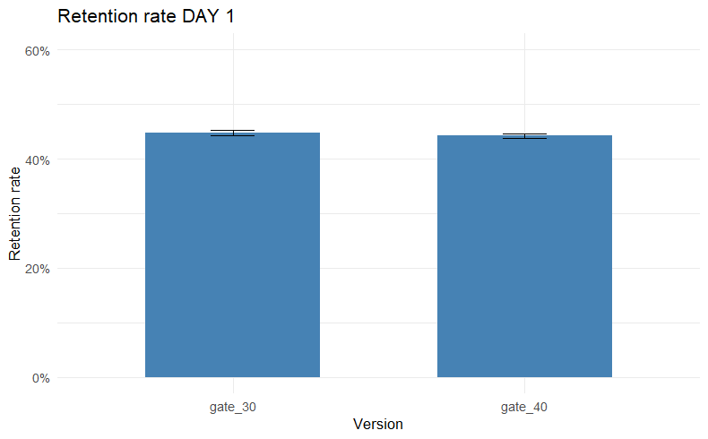

Day-1 Retention

# Conclusion

The two-proportion test did not detect a statistically significant difference in day 1 retention between the two groups (p = 0.0755). However, when adjusting for gameplay behavior using logistic regression, the treatment group (`gate_40`) showed a small but statistically significant decrease in retention odds compared to the control.

Given the imbalance in group sizes, and the borderline result in the unadjusted test, findings should be interpreted with some caution. Further validation is recommended using longer-term retention or downstream metrics.